# Data Preprocessing: Statistical Maps II

# Introduction

For this activity, I want students to think about spatial process. I plan to show them several maps and then ask them to try to “guess” the most likely value of a piece of information that is missing.

Load libraries:

```r
library(tidyverse)
library(spdep)
library(adespatial)
```

For this, I will create a set of random coordinates in the unit square:

```r
x <- runif(60)
y <- runif(60)
coords <- data.frame(x,y)
```

Plot coordinates:

```r
ggplot(data = coords, aes(x, y)) + geom_point(shape = 17, size = 2) + coord_fixed()
```

Now, to add some variables, I will use Moran Eigenvectors Maps. Begin by creating a list of nearest neighbors:

```r
nn5 <- knn2nb(knearneigh(as.matrix(coords), k = 5))
```

Based on the list of nearest neighbors I can create a W matrix (in list form):

```r
w5 <- nb2listw(nn5)
```

From which the MEM maps are obtained using the `adespatial::mem` function:

```r
EV <- mem(w5)
```

Scale the values of the EV:

```r
maxs <- apply(EV, 2, max)
mins <- apply(EV, 2, min)
EV <- 1000  * as.data.frame(scale(EV, center = mins, scale = maxs - mins)) + 50
```

Append selected EV to the coordinates:

```r
data <- coords
data$VAR1 <- EV$MEM12
```

Plot:

```r
ggplot(data = data, aes(x, y)) +
  geom_point(aes(color = VAR1), shape = 17, size = 2) +
  geom_point(color = "black", shape = 2, size = 2) +
  scale_color_distiller(type = "div", palette = "RdBu") +
  coord_fixed()
```

Append selected EV to the coordinates:

```r
data$VAR2 <- EV$MEM1
```

Plot:

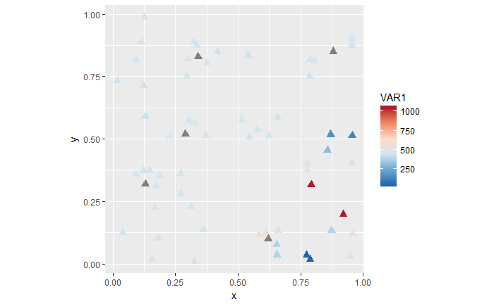

```r
ggplot(data = Data, aes(x, y)) +
  geom_point(aes(color = VAR1), shape = 17, size = 3) +
  scale_color_distiller(palette = "RdBu") +
  coord_fixed()
```

Append selected EV to the coordinates:

```r
data$VAR3 <- EV$MEM30
```

Plot:

```r
ggplot(data = data, aes(x, y)) +
  geom_point(aes(color = VAR3), shape = 17, size = 2) +
  geom_point(color = "black", shape = 2, size = 2) +
  scale_color_distiller(type = "div", palette = "RdBu") +
  coord_fixed()
```

Add coordinates for “guessing”:

```r
coords2 <- data.frame(matrix(c(0.34, 0.29, 0.13, 0.62, 0.88, 0.83, 0.52, 0.32, 0.1, 0.85), nrow=5, ncol=2) )
coords2 <- rename(coords2, x = X1, y = X2)
```

Add these coordinates to the plot:

```r
ggplot() +
  geom_point(data = data, aes(x = x, y = y, color = VAR3), shape = 17, size = 3) +
  geom_point(data = data, aes(x = x, y = y), color = "black", shape = 2, size = 3) +
  geom_point(data = coords2, aes (x = x, y = y), shape = 17, size = 4) +
  scale_color_distiller(type = "div", palette = "RdBu") +
  coord_fixed()
```

Recreate the dataset, including the locations of the “missing” observations:

```r
data_all <- rbind(coords, coords2)
nn5_all <- knn2nb(knearneigh(as.matrix(data_all), k = 5))
w5_all <- nb2listw(nn5_all)
EV_all <- mem(w5_all)
maxs <- apply(EV_all, 2, max)
mins <- apply(EV_all, 2, min)
EV_all <- 1000  * as.data.frame(scale(EV_all, center = mins, scale = maxs - mins)) + 50
data_all$VAR1 <- EV_all$MEM12
data_all$VAR2 <- EV_all$MEM1
data_all$VAR3 <- EV_all$MEM30
```

These are the actual values of the “missing” observations:

```r
Actual <- data_all[61:65,]
```

These are the observations:

```r
Observations <- data_all[1:60,]
```

These are the missing observations:

```r
Missing <- data_all[61:65,1:2]
```

Save data:

```r
save(Observations, Missing, file = "Data1.RData")
save(Actual, file = "Data1-Actual-Values.RData")
```

For the second part of the activity, I want students to think in terms of point patterns, and try to guess where the next event might occur. For this, I will generate two patterns, one with clustering and one completely random.

Random coordinates:

```r
x <- runif(60)
y <- runif(60)
coords <- data.frame(x,y)
```

```r
PointPattern1 <- coords
```

Plot coordinates:

```r
ggplot(data = PointPattern1, aes(x, y)) + geom_point(shape = 17, size = 2) + coord_fixed()
```

Clustered coordinates 1:

```r
x <- 0.20 + 0.10 * runif(10)
y <- 0.20 + 0.10 * runif(10)
PointPattern2 <- data.frame(x,y)
```

```r
x <- 0.70 + 0.10 * runif(10)
y <- 0.70 + 0.10 * runif(10)
junk <- data.frame(x,y)
PointPattern2 <- rbind(PointPattern2,junk)
```

```r
x <- 0.15 + 0.10 * runif(10)
y <- 0.75 + 0.10 * runif(10)
junk <- data.frame(x,y)
PointPattern2 <- rbind(PointPattern2,junk)
```

```r
x <- runif(30)
y <- runif(30)
junk <- data.frame(x,y)
PointPattern2 <- rbind(PointPattern2,junk)
```

Plot coordinates:

```r
ggplot(data = PointPattern2, aes(x, y)) + geom_point(shape = 17, size = 2) + coord_fixed()
```

Clustered coordinates 2:

```r
x <- 0.30 + 0.25 * runif(10)
y <- 0.30 + 0.25 * runif(10)
PointPattern3 <- data.frame(x,y)
```

```r
x <- 0.70 + 0.25 * runif(10)
y <- 0.70 + 0.25 * runif(10)
junk <- data.frame(x,y)
PointPattern3 <- rbind(PointPattern3,junk)
```

```r
x <- 0.30 + 0.25 * runif(10)
y <- 0.75 + 0.25 * runif(10)
junk <- data.frame(x,y)
PointPattern3 <- rbind(PointPattern3,junk)
```

```r
x <- runif(30)
y <- runif(30)
junk <- data.frame(x,y)
PointPattern3 <- rbind(PointPattern3,junk)
```

Plot coordinates:

```r
ggplot(data = PointPattern3, aes(x, y)) + geom_point(shape = 17, size = 2) + coord_fixed()
```

Save:

```r
save(PointPattern1, PointPattern2, PointPattern3, file = "Data2.RData")
```